# Part II - Impact of Prosper Loan Variables on Customers' Loan Status

## by Josephine Ochai

## Investigation Overview

In this investigation, I wanted to look at the main variables of the Prosper loan records that affected loan status. The major focus was on illustrating the influence of credit score and borrower interest rates on the loan status and on each other. I also illustrated how being a homeowner can affect one's credit score.

## Dataset Overview

The dataset consisted of approximately 114,000 records of Prosper loans with 81 attributes for each loan including -but not limited to- the loan status, loan original amount, borrower APR & interest rate, credit score, employment status of the individuals as well as their income range. For the purpose of my analysis, I wanted to investigate what attributes in the data affect loan status; I suspected the following attributes would have the most impact, so I limited the attributes in the dataset to just 11 variables and excluded all others.

The data contained some missing numerical and categorical values; for every numerical feature that had missing values, its mean value was imputed whereas the missing values found in the categorical features were dropped - 7741 data points in all.

## Distribution of Loan Status

The distribution of loan status in the dataset shows the majority of borrowers have a positive loan status (current or completed status) compared to borrowers who have defaulted or are past due payment date. A negligible number of borrowers have had their loans either canceled or having final payment in progress. All variations of 'past due' status with varying delinquency buckets were viewed as just 'past due' for the purpose of this analysis since they were in the minority.

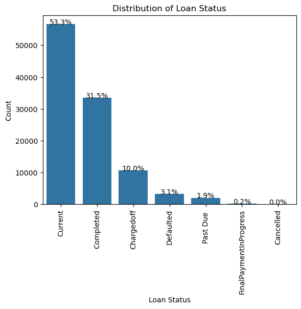

## Distribution of Credit Score

The credit score represents the rating of Prosper's borrowers based on their financial history. The distribution below is indicative of a possibility that Prosper usually requires their borrowers to have a minimum credit score of about 530 in order to be granted loans. Most loans are granted to borrowers with an average score of about 675 - 700.

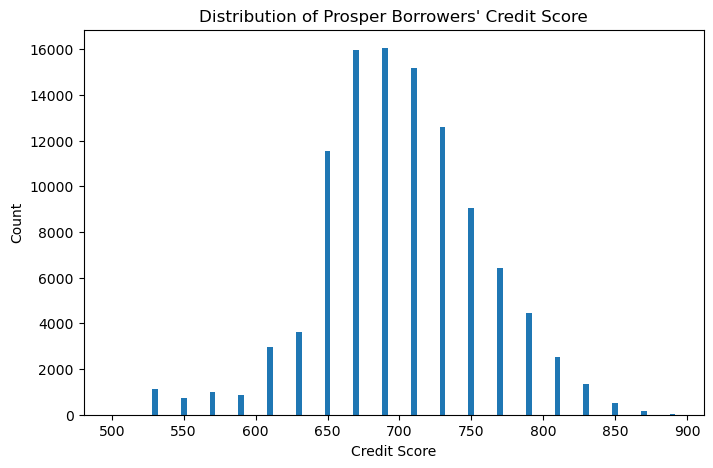

## Distribution of Borrower Rate

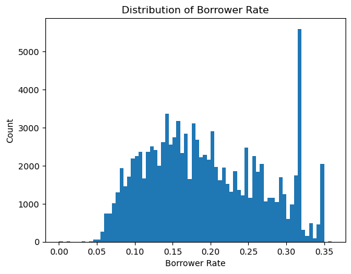

## Credit Score Vs Borrower Rate

The scatterplot below indicates that credit score mostly appears to be negatively correlated with the borrower's interest rate which is logical as Prosper might want to reward/entice those individuals with reputable financial status evident from their high credit scores with low interest rates to encourage loan requests with a reduced financial risk on their end. There are however, some few data points with low credit scores and low interest rates as well as points with high credit scores and high interest rates.

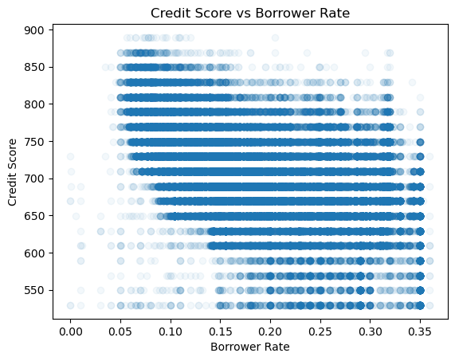

## Credit Score vs Borrower Rate - Ilustrating the Edge Cases Depicting Positive Correlation

Faceting the scatter plot above across the different categorical levels of loan status helps to zoom in on areas where Prosper issued more low interest rate loans to borrowers with low credit scores. These borrowers had loan status of either 'completed', 'defaulted' or 'charged off' as shown in the scatter plots below.

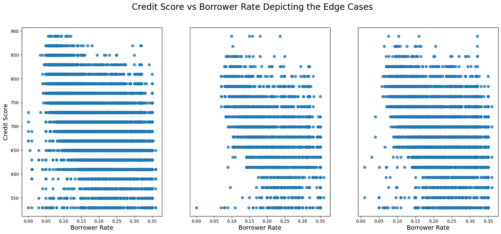

## Loan Status by Credit Score and Borrower Rate

The violin plots below show that there are more lower borrower rate values with corresponding high credit score values for loan records with either a 'completed' or 'current' loan status. Conversely, loans that have been defaulted, charged off or past due agreed payment timelines have lower credit scores and higher values for interest rates.

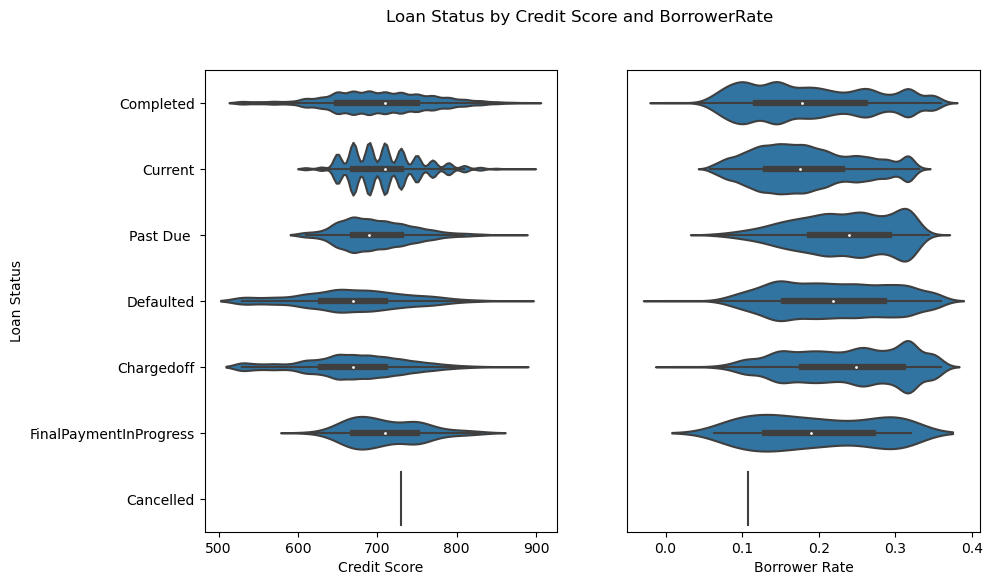

## Impact of Owning a Home on Credit Score

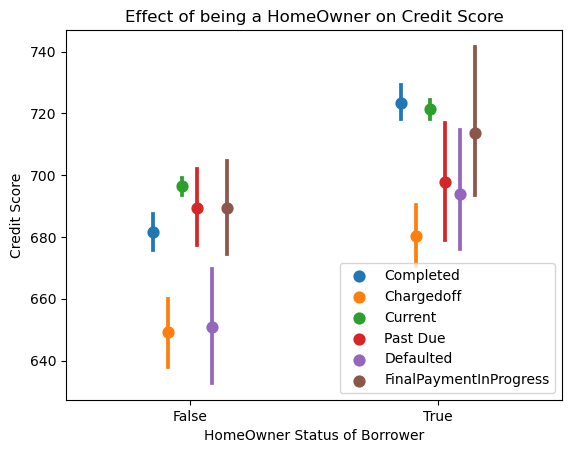